# Analiza danych na temat pierwszych wydań dzieł Stanisława Lema drukiem zwartym (EDA)

Olga Sieradzan

2023-12-14

# Potrzebne pakiety

```r
library(dplyr)
library(rvest)
library(mice)
library(ggplot2)
```

# Pobieranie danych z wikipedii

```r
url <- "https://pl.wikipedia.org/wiki/Lista_pierwszych_wyda%C5%84_dzie%C5%82_Stanis%C5%82awa_Lema_drukiem_zwartym"# Adres tabeli jaką chce pobrać

page <- read_html(url) # Wczytuje stronę internetową i tworzę drzewiastą strukturę html

tab2 <- page %>%
  html_nodes(css = "table.wikitable") # Wyszukuje węzły w drzewie pasujące do określonego wzorca (tzw. selectora)

tabela <- tab2[[1]] %>% html_table(fill=T)

# Pobrana tabela
tabela
```

```
## # A tibble: 67 × 7
##      Rok Tytuł       Zawartość `Wydawnictwo[a]` `Uwagi[b]` `Nakład[c]` `Link[d]`
##    <int> <chr>       <chr>     <chr>            <chr>      <chr>       <chr>
##  1  1951 Astronauci  Powieść … Spółdzielnia Wy… Pierwsza … 10 370      "[1]"
##  2  1951 Jacht „Par… Sztuka s… Spółdzielnia Oś… Współauto… 4 370       ""
##  3  1954 Sezam i in… Zbiór op… Państwowe Wydaw… Okładka: … 20 000+176  ""
##  4  1955 Czas nieut… Powieść … Wydawnictwo Lit… Pierwsza … 10 000+175  ""
##  5  1955 Obłok Mage… Powieść … Państwowe Wydaw… Okładka: … 20 000+205  "[2]"
##  6  1957 Dialogi     Eseje fu… Wydawnictwo Lit… Okładka: … 3 000+205   "[3]"
##  7  1957 Dzienniki … Zbiór op… Państwowe Wydaw… Okładka: … 20 000+205  "[4]"
##  8  1959 Eden        Powieść … Państwowe Wydaw… Okładka: … 20 000+250  "[5]"
##  9  1959 Inwazja z … Zbiór op… Wydawnictwo Lit… Obwoluta:… 10 000+205  ""
## 10  1959 Śledztwo    Powieść … Wydawnictwo Min… Okładka: … 50 000      "[6]"
## # ℹ 57 more rows
```

# Krótki opis danych

W tabeli mamy 7 kolumn i 67 wierszy dotyczących pierwszych wydań dzieł Stanisława Lema drukiem zwartym.

Uwzględnione zmienne:

- **Rok**

Rok wydania danej książki

- **Tytuł**

Tytuł danej książki

- **Zawartość**

Opis gatunku/tematyki danej książki.

- **Wydawnictwo**

Nazwa wydawnictwa które wydało pierwszy nakład danej książki.

- **Uwagi**

Dodatkowe informacje na temat książki np. Kto jest autorem okładki?, Czy ta ksiązka należy do jakiejś serii? itd.

- **Nakład**

Ilość wydanych książek w pierwszym nakładzie.

- **Linki**

Hiperłącza do artykułów zawierających informacje na temat danej książki.

# Przygotowanie tabeli do analizy

Po pierwsze usuwam kolumnę Uwagi oraz Link ponieważ nie przydadzą się do mojej analizy.

```r
tabela <- tabela[, -c(5,7)]
```

Ponad to muszę się zająć kolumną Nakład i poprawić nazwy kolumn.

```r
tabela[,5]<-c (10370,4370,20176,10175,20205,30205,20205,20250,10205,50000,10250,10253,
               20250,10000,2753,10251,7290,10290,3251,10290,7290,20300,3283,10280,20283,
               5283,30283,20290,30290,10283,20290,40283,100283,40283,50300,80350,50350,50530,
               100350,100283,100283,rep(NA,26))

names(tabela)<- c ("Rok","Tytuł","Zawartość", "Wydawnictwo", "Nakład")
```

Teraz sprawdzenie braków danych.

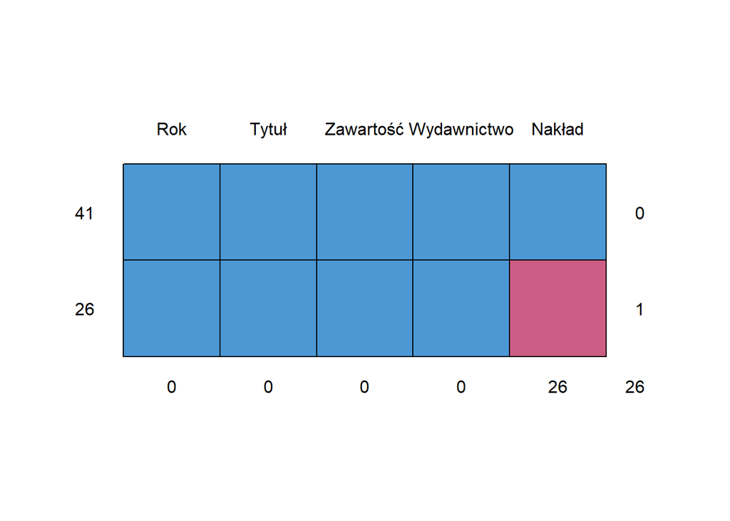

```
##    Rok Tytuł Zawartość Wydawnictwo Nakład
## 41   1     1         1           1      1  0
## 26   1     1         1           1      0  1
##      0     0         0           0     26 26
```

```r
md.pattern(tabela)
```

Widać że mamy tylko braki w kolumnie Nakład które już wcześniej zauważyłam, dlatego postanawiam je zamienić na mediane nakładów.

```r
tabela %>%
  summarise( Mediana = median ( Nakład, na.rm = T))
```

```
## # A tibble: 1 × 1
##   Mediana
##     <dbl>
## 1   20205
```

```r
tabela[42:67,5] <- 20205
```

Teraz już mogę przejść do przeanalizowanie powyższego zbioru danych.

# Analiza

Na sam poczatek chce sprawdzić jak wygląda rozkład nakładów na książki Lema.

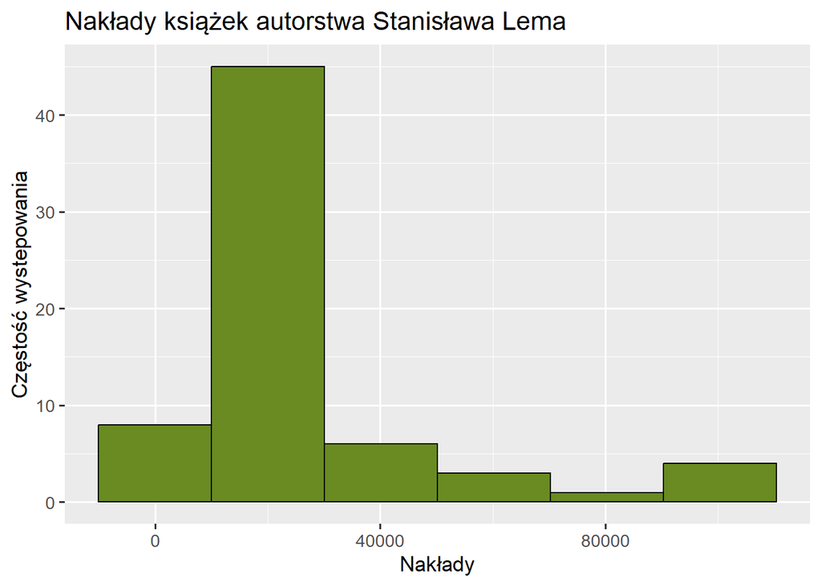

```r
# Wizualizacja
tabela%>%
  ggplot(aes ( x = Nakład ))+
  geom_histogram( color = "black", fill = "olivedrab4", bins =5 , binwidth =(100350/5) ) +
  theme_grey( base_size = 13) +
  labs( title= "Nakłady książek autorstwa Stanisława Lema",
        x = "Nakłady",
        y = "Częstość wystepowania")
```

Następnie sprawdzam jak zmieniał sie nakład książek Lema wraz z czasem.

Wykorzystam do tego lata z których miałam dane, nie uwzgledniam lat dla których uzupełniłam wartość nakładów medianą.

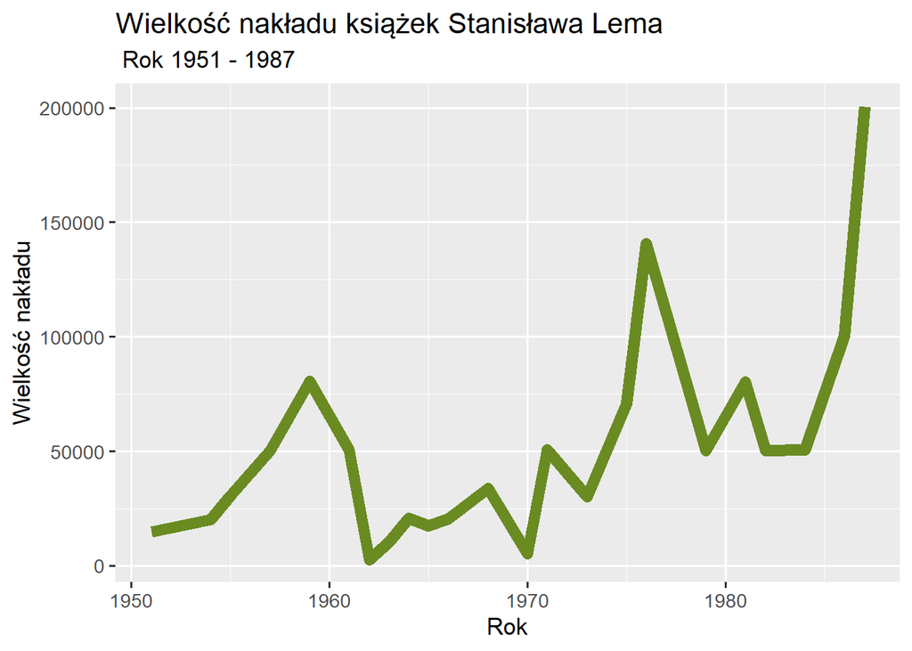

```r
# Obliczenie sum dla poszczególnych lat
Sumy_Nakładów <- tabela %>%
                  filter(Rok %in% c(1951:1987))%>%
                  group_by(Rok)%>%
                  summarise(Suma_Nakładu = sum(Nakład))

# Wizualizacja
Sumy_Nakładów %>%
  ggplot(aes(x = Rok , y = Suma_Nakładu)) +
  geom_line(size = 3, col = "olivedrab4") +
  labs( title = "Wielkość nakładu książek Stanisława Lema",
        subtitle = " Rok 1951 - 1987 ",
        x = "Rok",
        y = "Wielkość nakładu")+
  theme_grey(base_size = 13)
```

Teraz chce sprawdzić zawartość twórczości Lema. Jednak w tym zbiorze danych jest ten podział bardzo wyszczegółowiony przez co mamy aż 40 rodzajów zawartości książek Lema.

Uproszcze ten podział, na bardziej ogólne kategorie, na potrzeby analizy.

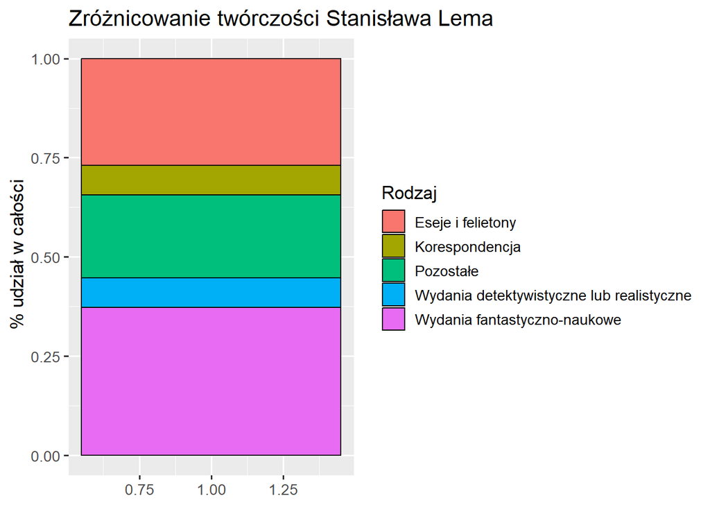

```r
#Podział zawartości ksiązek Lema na bardziej ogólne kategorie

Eseje_i_felietony <- c("Eseje filozoficzne, publicystyka literacka" , "Eseje futurologiczno-filozoficzne", "Eseje futurologiczno-filozoficzne, publicystyka literacka",
                       "Eseje i publicystyka literacka", "Wybór esejów", "Wybór felietonów", "Wybór felietonów publikowanych w „Tygodniku Powszechnym” w latach 1994–2004",
                       "Zbiór esejów","Zbiór felietonów", "Zbiór esejów publikowanych w polskiej edycji czasopisma „PC Magazine”","Zbiór felietonów i esejów",
                       "Zbiór felietonów publikowanych w „Tygodniku Powszechnym” w latach 1994-95 w ramach serii „Świat według Lema”",
                       "Zbiór felietonów publikowanych w „Tygodniku Powszechnym” w latach 1995-97 w ramach serii „Świat według Lema”",
                       "Zbiór felietonów publikowanych w „Tygodniku Powszechnym” w latach 2005–2006"
                       )

Korespondencja <- c("Korespondencja Lema z Michaelem Kandlem z lat 1972–1987", "Korespondencja Lema ze Sławomirem Mrożkiem z lat 1956–1978",
                    "Korespondencja z Ewą Lipską", "Wybór listów autora do różnych osób i instytucji", "Wybór listów z okresu PRL")

Wydania_fantastyczno_naukowe <-c("Kongres futurologiczny i cztery opowiadania fantastyczno-naukowe", "Minipowieść Niezwyciężony i zbiór opowiadań fantastyczno-naukowych",
                                 "Opowiadanie fantastyczno-naukowe i scenariusze słuchowisk radiowych", "Powieść fantastyczno-naukowa","Zbiór opowiadań fantastyczno-naukowych",
                                 "Zbiór opowiadań fantastyczno-naukowych i scenariuszy widowisk telewizyjnych ")

Wydania_detektyfistyczne_lub_realistyczne <- c("Niedokończona powieść kryminalna Sknocony kryminał, dramat Korzenie. Drrama wieloaktowe oraz Dyktanda",
                                               "Powieść detektywistyczna", "Powieść realistyczna", "Powieść realistyczna (trylogia)")

# Dodanie nowej kolumny z podziałem, do tabeli na której pracuje

tabela <- tabela %>%
  mutate (Rodzaj = ifelse( Zawartość %in% Eseje_i_felietony, "Eseje i felietony",
                   ifelse( Zawartość %in% Korespondencja, "Korespondencja",
                   ifelse( Zawartość %in% Wydania_fantastyczno_naukowe, "Wydania fantastyczno-naukowe",
                   ifelse ( Zawartość %in% Wydania_detektyfistyczne_lub_realistyczne,
                            "Wydania detektywistyczne lub realistyczne", "Pozostałe"
                   )))))

# Wizualizacja

tabela %>%
  ggplot()+
  geom_bar( aes ( x = 1,fill = Rodzaj ), color = "black", position = "fill") +
  theme_gray(base_size = 13) +
  labs( title = "Zróżnicowanie twórczości Stanisława Lema",
        y = " % udział w całości",
        x = NULL)
```

Najwiekszą częścią twórczości Lema są wydania fantastyczno-naukowe, jest z nich najbardziej znany. Takie książki jak “Solaris” czy “Dzienniki gwiazdowe” , są nawet uwzględnione w kanonie lektur szkolnych. Mniej osób jednak wie o tym, że Lem był również filozofem i futurologiem. Idealnym przykładem jest książka “GOLEM XIV”. Tekst książki wywołuje wrażenie jakby opisywał aktualne wydażenia, a przecież został wydany w roku 1981.

Teraz sprawdzę jak wyglądał przeciętny nakład na każdy z tych rodzajów.

```r
# Obliczenie przecietnego nakładu

( Przecietny_Nakład <- tabela %>%
  group_by(Rodzaj) %>%
  summarise( przeciętny_nakład = mean(Nakład)) %>%
    arrange(desc(przeciętny_nakład)))
```

```
## # A tibble: 5 × 2
##   Rodzaj                                    przeciętny_nakład
##   <chr>                                                 <dbl>
## 1 Wydania detektywistyczne lub realistyczne            40191.
## 2 Pozostałe                                            29855.
## 3 Wydania fantastyczno-naukowe                         27614.
## 4 Korespondencja                                       20205
## 5 Eseje i felietony                                    16529.
```

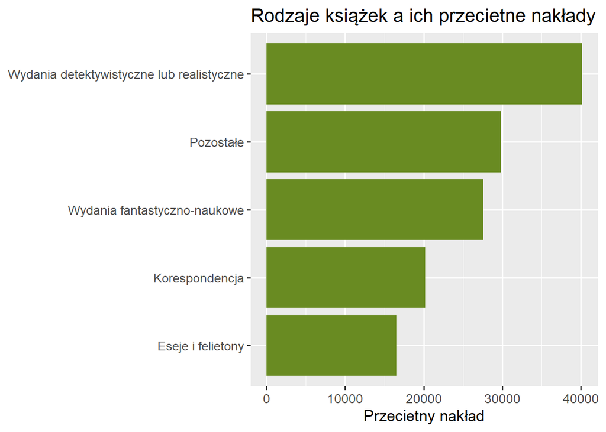

```r
# Wizualizacja

Przecietny_Nakład %>%
  ggplot( aes( y = reorder(Rodzaj,przeciętny_nakład),
               x = przeciętny_nakład))+
  geom_col(size = 3, fill = "olivedrab4") +
  theme_gray(base_size = 13)+
  labs( title = "Rodzaje książek a ich przecietne nakłady",
        y = NULL,
        x = "Przecietny nakład")
```

Ku mojemu zdziweniu to nie literatura fantastyczno-naukowa doczekała się najwiekszych nakładów pierwszych wydań, lecz wydania detektywistyczne lub realistyczne.

```r
# Wybór ksiązek z kategorii detektywistyczne lub realistczne
tabela %>%
  filter(Rodzaj == "Wydania detektywistyczne lub realistyczne")%>%
  select( Rok , Tytuł, Nakład)
```

```
## # A tibble: 5 × 3
##     Rok Tytuł                 Nakład
##   <int> <chr>                  <dbl>
## 1  1955 Czas nieutracony       10175
## 2  1959 Śledztwo               50000
## 3  1975 Szpital Przemienienia  20290
## 4  1976 Katar                 100283
## 5  2009 Sknocony kryminał      20205
```

Patrząc na dane widzimy dwa bardzo duże nakłady. Jeden dla “Śledzctwa”, które między innymi jest o potędze statystyki, a drugi dla “Kataru”. Ciekawostką jest to że te dwa teksty na poczatku miały być jedną książką, lecz autor postanowił je rozdzielić i wydać osobno.

Ostatnią kwestią jaką chce się zająć to, które wydawnictwa wydawały najwiecej książek Lema.

```r
( Wydawnictwa <-tabela %>%
  group_by(Wydawnictwo) %>%
  summarise( Sumy_Nakładów = sum (Nakład)) %>%
    arrange(desc(Sumy_Nakładów)))
```

```
## # A tibble: 13 × 2
##    Wydawnictwo                                                     Sumy_Nakładów
##    <chr>                                                                   <dbl>
##  1 Wydawnictwo Literackie                                                1157653
##  2 Państwowe Wydawnictwo „Iskry”                                          141386
##  3 „Czytelnik”                                                            101400
##  4 Wydawnictwo Ministerstwa Obrony Narodowej                               90590
##  5 Agora SA                                                                40410
##  6 Niezależna Oficyna Wydawnicza „Nowa”                                    40410
##  7 Społeczny Instytut Wydawniczy „Znak”                                    40410
##  8 Przedsięwzięcie Galicja                                                 20205
##  9 Towarzystwo Autorów i Wydawców Prac Naukowych „Universitas”             20205
## 10 Wydawnictwo Interart                                                    20205
## 11 Wydawnictwo Polskiego Towarzystwa Wydawców Książek i Wydawnict…         20205
## 12 Spółdzielnia Wydawniczo-Oświatowa „Czytelnik”                           10370
## 13 Spółdzielnia Oświatowo-Wydawnicza „Czytelnik”                            4370
```

Zdecydowanie przoduje Wydawnictwo Literackie z aż ponad milionowym nakładem na teksty Stanisława Lema.

Jeżeli chodzi o wydawanie książęk Lema , Wydawnictwo Literackie nadal przoduje. W 2020 roku ponownie wydali kolekcje tekstów autora, z przepieknymi okładkami.

**Dziękuje bardzo za uwagę**